# Risk Factor Analysis

## Outcome Variable

**Outcome Variable:** ever_stunted

## Predictor Variables

**Intervention Variable:** perdiar6

**Adjustment Set:**

unadjusted

## Stratifying Variables

The analysis was stratified on these variable(s):

- agecat
- studyid
- country

## Data Summary

| agecat | studyid | country | perdiar6 | ever_stunted | n_cell | n |
| --- | --- | --- | --- | --- | --- | --- |
| 0-24 months (no birth st.) | ki0047075b-MAL-ED | BANGLADESH | (0%, 5%] | 0 | 41 | 217 |
| 0-24 months (no birth st.) | ki0047075b-MAL-ED | BANGLADESH | (0%, 5%] | 1 | 44 | 217 |
| 0-24 months (no birth st.) | ki0047075b-MAL-ED | BANGLADESH | 0% | 0 | 36 | 217 |
| 0-24 months (no birth st.) | ki0047075b-MAL-ED | BANGLADESH | 0% | 1 | 36 | 217 |
| 0-24 months (no birth st.) | ki0047075b-MAL-ED | BANGLADESH | >5% | 0 | 27 | 217 |
| 0-24 months (no birth st.) | ki0047075b-MAL-ED | BANGLADESH | >5% | 1 | 33 | 217 |
| 0-24 months (no birth st.) | ki0047075b-MAL-ED | BRAZIL | (0%, 5%] | 0 | 12 | 208 |
| 0-24 months (no birth st.) | ki0047075b-MAL-ED | BRAZIL | (0%, 5%] | 1 | 2 | 208 |
| 0-24 months (no birth st.) | ki0047075b-MAL-ED | BRAZIL | 0% | 0 | 165 | 208 |
| 0-24 months (no birth st.) | ki0047075b-MAL-ED | BRAZIL | 0% | 1 | 27 | 208 |
| 0-24 months (no birth st.) | ki0047075b-MAL-ED | BRAZIL | >5% | 0 | 2 | 208 |
| 0-24 months (no birth st.) | ki0047075b-MAL-ED | BRAZIL | >5% | 1 | 0 | 208 |
| 0-24 months (no birth st.) | ki0047075b-MAL-ED | INDIA | (0%, 5%] | 0 | 54 | 209 |
| 0-24 months (no birth st.) | ki0047075b-MAL-ED | INDIA | (0%, 5%] | 1 | 52 | 209 |
| 0-24 months (no birth st.) | ki0047075b-MAL-ED | INDIA | 0% | 0 | 24 | 209 |
| 0-24 months (no birth st.) | ki0047075b-MAL-ED | INDIA | 0% | 1 | 25 | 209 |
| 0-24 months (no birth st.) | ki0047075b-MAL-ED | INDIA | >5% | 0 | 23 | 209 |
| 0-24 months (no birth st.) | ki0047075b-MAL-ED | INDIA | >5% | 1 | 31 | 209 |
| 0-24 months (no birth st.) | ki0047075b-MAL-ED | NEPAL | (0%, 5%] | 0 | 54 | 212 |
| 0-24 months (no birth st.) | ki0047075b-MAL-ED | NEPAL | (0%, 5%] | 1 | 14 | 212 |
| 0-24 months (no birth st.) | ki0047075b-MAL-ED | NEPAL | 0% | 0 | 54 | 212 |
| 0-24 months (no birth st.) | ki0047075b-MAL-ED | NEPAL | 0% | 1 | 20 | 212 |
| 0-24 months (no birth st.) | ki0047075b-MAL-ED | NEPAL | >5% | 0 | 49 | 212 |
| 0-24 months (no birth st.) | ki0047075b-MAL-ED | NEPAL | >5% | 1 | 21 | 212 |
| 0-24 months (no birth st.) | ki0047075b-MAL-ED | PERU | (0%, 5%] | 0 | 29 | 266 |
| 0-24 months (no birth st.) | ki0047075b-MAL-ED | PERU | (0%, 5%] | 1 | 51 | 266 |
| 0-24 months (no birth st.) | ki0047075b-MAL-ED | PERU | 0% | 0 | 37 | 266 |
| 0-24 months (no birth st.) | ki0047075b-MAL-ED | PERU | 0% | 1 | 40 | 266 |
| 0-24 months (no birth st.) | ki0047075b-MAL-ED | PERU | >5% | 0 | 49 | 266 |
| 0-24 months (no birth st.) | ki0047075b-MAL-ED | PERU | >5% | 1 | 60 | 266 |

[output cut: 258 more lines]

The following strata were considered:

- agecat: 0-24 months (no birth st.), studyid: ki0047075b-MAL-ED, country: BANGLADESH
- agecat: 0-24 months (no birth st.), studyid: ki0047075b-MAL-ED, country: BRAZIL
- agecat: 0-24 months (no birth st.), studyid: ki0047075b-MAL-ED, country: INDIA
- agecat: 0-24 months (no birth st.), studyid: ki0047075b-MAL-ED, country: NEPAL
- agecat: 0-24 months (no birth st.), studyid: ki0047075b-MAL-ED, country: PERU
- agecat: 0-24 months (no birth st.), studyid: ki0047075b-MAL-ED, country: SOUTH AFRICA
- agecat: 0-24 months (no birth st.), studyid: ki0047075b-MAL-ED, country: TANZANIA, UNITED REPUBLIC OF
- agecat: 0-24 months (no birth st.), studyid: ki1000109-ResPak, country: PAKISTAN
- agecat: 0-24 months (no birth st.), studyid: ki1017093-NIH-Birth, country: BANGLADESH
- agecat: 0-24 months (no birth st.), studyid: ki1017093b-PROVIDE, country: BANGLADESH
- agecat: 0-24 months (no birth st.), studyid: ki1017093c-NIH-Crypto, country: BANGLADESH
- agecat: 0-24 months (no birth st.), studyid: ki1114097-CMIN, country: BANGLADESH
- agecat: 0-24 months (no birth st.), studyid: ki1114097-CMIN, country: BRAZIL
- agecat: 0-24 months (no birth st.), studyid: ki1114097-CMIN, country: GUINEA-BISSAU
- agecat: 0-24 months (no birth st.), studyid: ki1114097-CMIN, country: PERU
- agecat: 0-24 months (no birth st.), studyid: ki1114097-CONTENT, country: PERU
- agecat: 0-6 months (no birth st.), studyid: ki0047075b-MAL-ED, country: BANGLADESH
- agecat: 0-6 months (no birth st.), studyid: ki0047075b-MAL-ED, country: BRAZIL
- agecat: 0-6 months (no birth st.), studyid: ki0047075b-MAL-ED, country: INDIA
- agecat: 0-6 months (no birth st.), studyid: ki0047075b-MAL-ED, country: NEPAL
- agecat: 0-6 months (no birth st.), studyid: ki0047075b-MAL-ED, country: PERU
- agecat: 0-6 months (no birth st.), studyid: ki0047075b-MAL-ED, country: SOUTH AFRICA
- agecat: 0-6 months (no birth st.), studyid: ki0047075b-MAL-ED, country: TANZANIA, UNITED REPUBLIC OF
- agecat: 0-6 months (no birth st.), studyid: ki1000109-ResPak, country: PAKISTAN
- agecat: 0-6 months (no birth st.), studyid: ki1017093-NIH-Birth, country: BANGLADESH
- agecat: 0-6 months (no birth st.), studyid: ki1017093b-PROVIDE, country: BANGLADESH
- agecat: 0-6 months (no birth st.), studyid: ki1017093c-NIH-Crypto, country: BANGLADESH
- agecat: 0-6 months (no birth st.), studyid: ki1114097-CMIN, country: BANGLADESH
- agecat: 0-6 months (no birth st.), studyid: ki1114097-CMIN, country: BRAZIL
- agecat: 0-6 months (no birth st.), studyid: ki1114097-CMIN, country: GUINEA-BISSAU
- agecat: 0-6 months (no birth st.), studyid: ki1114097-CMIN, country: PERU
- agecat: 0-6 months (no birth st.), studyid: ki1114097-CONTENT, country: PERU
- agecat: 6-24 months, studyid: ki0047075b-MAL-ED, country: BANGLADESH
- agecat: 6-24 months, studyid: ki0047075b-MAL-ED, country: BRAZIL
- agecat: 6-24 months, studyid: ki0047075b-MAL-ED, country: INDIA
- agecat: 6-24 months, studyid: ki0047075b-MAL-ED, country: NEPAL
- agecat: 6-24 months, studyid: ki0047075b-MAL-ED, country: PERU
- agecat: 6-24 months, studyid: ki0047075b-MAL-ED, country: SOUTH AFRICA
- agecat: 6-24 months, studyid: ki0047075b-MAL-ED, country: TANZANIA, UNITED REPUBLIC OF
- agecat: 6-24 months, studyid: ki1000109-ResPak, country: PAKISTAN
- agecat: 6-24 months, studyid: ki1017093-NIH-Birth, country: BANGLADESH
- agecat: 6-24 months, studyid: ki1017093b-PROVIDE, country: BANGLADESH
- agecat: 6-24 months, studyid: ki1017093c-NIH-Crypto, country: BANGLADESH
- agecat: 6-24 months, studyid: ki1114097-CMIN, country: BANGLADESH
- agecat: 6-24 months, studyid: ki1114097-CMIN, country: BRAZIL
- agecat: 6-24 months, studyid: ki1114097-CMIN, country: GUINEA-BISSAU
- agecat: 6-24 months, studyid: ki1114097-CMIN, country: PERU
- agecat: 6-24 months, studyid: ki1114097-CONTENT, country: PERU

### Dropped Strata

Some strata were dropped due to rare outcomes:

- agecat: 0-24 months (no birth st.), studyid: ki0047075b-MAL-ED, country: BRAZIL
- agecat: 0-24 months (no birth st.), studyid: ki0047075b-MAL-ED, country: SOUTH AFRICA
- agecat: 0-6 months (no birth st.), studyid: ki0047075b-MAL-ED, country: BRAZIL
- agecat: 0-6 months (no birth st.), studyid: ki0047075b-MAL-ED, country: NEPAL
- agecat: 0-6 months (no birth st.), studyid: ki0047075b-MAL-ED, country: SOUTH AFRICA
- agecat: 0-6 months (no birth st.), studyid: ki1114097-CMIN, country: BRAZIL
- agecat: 0-6 months (no birth st.), studyid: ki1114097-CMIN, country: GUINEA-BISSAU
- agecat: 0-6 months (no birth st.), studyid: ki1114097-CONTENT, country: PERU
- agecat: 6-24 months, studyid: ki0047075b-MAL-ED, country: BRAZIL
- agecat: 6-24 months, studyid: ki0047075b-MAL-ED, country: SOUTH AFRICA
- agecat: 6-24 months, studyid: ki1000109-ResPak, country: PAKISTAN
- agecat: 6-24 months, studyid: ki1114097-CONTENT, country: PERU

## Methods Detail

We’re interested in the causal parameters $E[Y_a]$ for all values of $a \in \mathcal{A}$. These parameters represent the mean outcome if, possibly contrary to fact, we intervened to set all units to have $A=a$. Under the randomization and positivity assumptions, these are identified by the statistical parameters $\psi_a=E_W[E_{Y|A,W}(Y|A=a,W)]$. In addition, we’re interested in the mean of $Y$, $E[Y]$ under no intervention (the observed mean). We will estimate these parameters by using SuperLearner to fit the relevant likelihood factors – $E_{Y|A,W}(Y|A=a,W)$ and $p(A=a|W)$, and then updating our likelihood fit using a joint TMLE.

For unadjusted analyses ($W=\{\}$), initial likelihoods were estimated using Lrnr_glm to estimate the simple $E(Y|A)$ and Lrnr_mean to estimate $p(A)$. For adjusted analyses, a small library containing Lrnr_glmnet, Lrnr_xgboost, and Lrnr_mean was used.

Having estimated these parameters, we will then use the delta method to estimate relative risks and attributable risks relative to a prespecified baseline level of $A$.

# Results Detail

## Results Plots

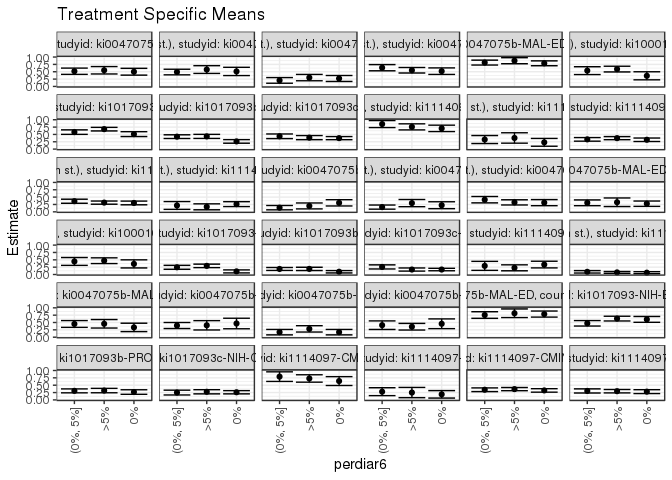

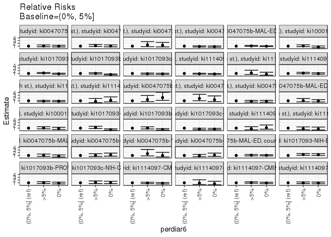

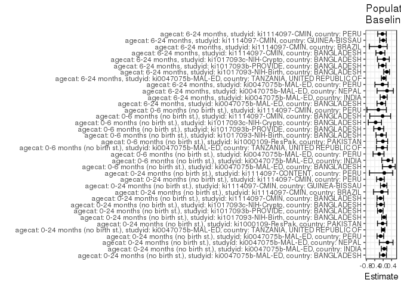

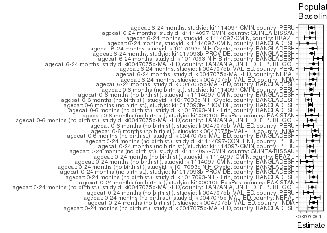

## Results Table

### Parameter: TSM

| agecat | studyid | country | intervention_level | baseline_level | estimate | ci_lower | ci_upper |
| --- | --- | --- | --- | --- | --- | --- | --- |
| 0-24 months (no birth st.) | ki0047075b-MAL-ED | BANGLADESH | (0%, 5%] | NA | 0.5176471 | 0.4111737 | 0.6241204 |
| 0-24 months (no birth st.) | ki0047075b-MAL-ED | BANGLADESH | 0% | NA | 0.5000000 | 0.3842410 | 0.6157590 |
| 0-24 months (no birth st.) | ki0047075b-MAL-ED | BANGLADESH | >5% | NA | 0.5500000 | 0.4238280 | 0.6761720 |
| 0-24 months (no birth st.) | ki0047075b-MAL-ED | INDIA | (0%, 5%] | NA | 0.4905660 | 0.3951702 | 0.5859619 |
| 0-24 months (no birth st.) | ki0047075b-MAL-ED | INDIA | 0% | NA | 0.5102041 | 0.3698998 | 0.6505084 |
| 0-24 months (no birth st.) | ki0047075b-MAL-ED | INDIA | >5% | NA | 0.5740741 | 0.4418703 | 0.7062778 |
| 0-24 months (no birth st.) | ki0047075b-MAL-ED | NEPAL | (0%, 5%] | NA | 0.2058824 | 0.1095500 | 0.3022147 |
| 0-24 months (no birth st.) | ki0047075b-MAL-ED | NEPAL | 0% | NA | 0.2702703 | 0.1688467 | 0.3716939 |
| 0-24 months (no birth st.) | ki0047075b-MAL-ED | NEPAL | >5% | NA | 0.3000000 | 0.1923943 | 0.4076057 |
| 0-24 months (no birth st.) | ki0047075b-MAL-ED | PERU | (0%, 5%] | NA | 0.6375000 | 0.5319605 | 0.7430395 |
| 0-24 months (no birth st.) | ki0047075b-MAL-ED | PERU | 0% | NA | 0.5194805 | 0.4076756 | 0.6312854 |
| 0-24 months (no birth st.) | ki0047075b-MAL-ED | PERU | >5% | NA | 0.5504587 | 0.4568966 | 0.6440208 |
| 0-24 months (no birth st.) | ki0047075b-MAL-ED | TANZANIA, UNITED REPUBLIC OF | (0%, 5%] | NA | 0.8117647 | 0.7284737 | 0.8950557 |
| 0-24 months (no birth st.) | ki0047075b-MAL-ED | TANZANIA, UNITED REPUBLIC OF | 0% | NA | 0.7872340 | 0.7043099 | 0.8701582 |
| 0-24 months (no birth st.) | ki0047075b-MAL-ED | TANZANIA, UNITED REPUBLIC OF | >5% | NA | 0.8750000 | 0.7722762 | 0.9777238 |
| 0-24 months (no birth st.) | ki1000109-ResPak | PAKISTAN | (0%, 5%] | NA | 0.5370370 | 0.4037127 | 0.6703614 |
| 0-24 months (no birth st.) | ki1000109-ResPak | PAKISTAN | 0% | NA | 0.3617021 | 0.2239909 | 0.4994134 |
| 0-24 months (no birth st.) | ki1000109-ResPak | PAKISTAN | >5% | NA | 0.5900000 | 0.4933618 | 0.6866382 |
| 0-24 months (no birth st.) | ki1017093-NIH-Birth | BANGLADESH | (0%, 5%] | NA | 0.5786164 | 0.5017926 | 0.6554401 |
| 0-24 months (no birth st.) | ki1017093-NIH-Birth | BANGLADESH | 0% | NA | 0.5106383 | 0.4280494 | 0.5932272 |
| 0-24 months (no birth st.) | ki1017093-NIH-Birth | BANGLADESH | >5% | NA | 0.6798246 | 0.6192089 | 0.7404402 |
| 0-24 months (no birth st.) | ki1017093b-PROVIDE | BANGLADESH | (0%, 5%] | NA | 0.4243697 | 0.3615283 | 0.4872112 |
| 0-24 months (no birth st.) | ki1017093b-PROVIDE | BANGLADESH | 0% | NA | 0.2623762 | 0.2016614 | 0.3230911 |
| 0-24 months (no birth st.) | ki1017093b-PROVIDE | BANGLADESH | >5% | NA | 0.4329897 | 0.3632108 | 0.5027686 |
| 0-24 months (no birth st.) | ki1017093c-NIH-Crypto | BANGLADESH | (0%, 5%] | NA | 0.4370861 | 0.3579095 | 0.5162627 |
| 0-24 months (no birth st.) | ki1017093c-NIH-Crypto | BANGLADESH | 0% | NA | 0.3738019 | 0.3201623 | 0.4274415 |
| 0-24 months (no birth st.) | ki1017093c-NIH-Crypto | BANGLADESH | >5% | NA | 0.3915344 | 0.3218953 | 0.4611735 |
| 0-24 months (no birth st.) | ki1114097-CMIN | BANGLADESH | (0%, 5%] | NA | 0.8529412 | 0.7335396 | 0.9723428 |
| 0-24 months (no birth st.) | ki1114097-CMIN | BANGLADESH | 0% | NA | 0.7058824 | 0.5972606 | 0.8145041 |
| 0-24 months (no birth st.) | ki1114097-CMIN | BANGLADESH | >5% | NA | 0.7575758 | 0.6538770 | 0.8612745 |

[output cut: 78 more lines]

### Parameter: E(Y)

| agecat | studyid | country | intervention_level | baseline_level | estimate | ci_lower | ci_upper |
| --- | --- | --- | --- | --- | --- | --- | --- |
| 0-24 months (no birth st.) | ki0047075b-MAL-ED | BANGLADESH | NA | NA | 0.5207373 | 0.4541154 | 0.5873593 |
| 0-24 months (no birth st.) | ki0047075b-MAL-ED | INDIA | NA | NA | 0.5167464 | 0.4488350 | 0.5846578 |
| 0-24 months (no birth st.) | ki0047075b-MAL-ED | NEPAL | NA | NA | 0.2594340 | 0.2002911 | 0.3185768 |
| 0-24 months (no birth st.) | ki0047075b-MAL-ED | PERU | NA | NA | 0.5676692 | 0.5080232 | 0.6273151 |
| 0-24 months (no birth st.) | ki0047075b-MAL-ED | TANZANIA, UNITED REPUBLIC OF | NA | NA | 0.8127854 | 0.7610035 | 0.8645672 |
| 0-24 months (no birth st.) | ki1000109-ResPak | PAKISTAN | NA | NA | 0.5223881 | 0.4531624 | 0.5916138 |
| 0-24 months (no birth st.) | ki1017093-NIH-Birth | BANGLADESH | NA | NA | 0.6041667 | 0.5624147 | 0.6459187 |
| 0-24 months (no birth st.) | ki1017093b-PROVIDE | BANGLADESH | NA | NA | 0.3753943 | 0.3376725 | 0.4131162 |
| 0-24 months (no birth st.) | ki1017093c-NIH-Crypto | BANGLADESH | NA | NA | 0.3935681 | 0.3560687 | 0.4310676 |
| 0-24 months (no birth st.) | ki1114097-CMIN | BANGLADESH | NA | NA | 0.7559524 | 0.6908084 | 0.8210964 |
| 0-24 months (no birth st.) | ki1114097-CMIN | BRAZIL | NA | NA | 0.3070175 | 0.2219720 | 0.3920631 |
| 0-24 months (no birth st.) | ki1114097-CMIN | GUINEA-BISSAU | NA | NA | 0.3443038 | 0.3111501 | 0.3774575 |
| 0-24 months (no birth st.) | ki1114097-CMIN | PERU | NA | NA | 0.3229167 | 0.2875370 | 0.3582963 |
| 0-24 months (no birth st.) | ki1114097-CONTENT | PERU | NA | NA | 0.2284264 | 0.1696529 | 0.2871999 |
| 0-6 months (no birth st.) | ki0047075b-MAL-ED | BANGLADESH | NA | NA | 0.2119816 | 0.1574763 | 0.2664868 |
| 0-6 months (no birth st.) | ki0047075b-MAL-ED | INDIA | NA | NA | 0.2105263 | 0.1551227 | 0.2659300 |
| 0-6 months (no birth st.) | ki0047075b-MAL-ED | PERU | NA | NA | 0.3458647 | 0.2885967 | 0.4031327 |
| 0-6 months (no birth st.) | ki0047075b-MAL-ED | TANZANIA, UNITED REPUBLIC OF | NA | NA | 0.2968037 | 0.2361590 | 0.3574483 |
| 0-6 months (no birth st.) | ki1000109-ResPak | PAKISTAN | NA | NA | 0.4378109 | 0.3690538 | 0.5065681 |
| 0-6 months (no birth st.) | ki1017093-NIH-Birth | BANGLADESH | NA | NA | 0.2291667 | 0.1932828 | 0.2650505 |
| 0-6 months (no birth st.) | ki1017093b-PROVIDE | BANGLADESH | NA | NA | 0.1593060 | 0.1307970 | 0.1878149 |
| 0-6 months (no birth st.) | ki1017093c-NIH-Crypto | BANGLADESH | NA | NA | 0.1898928 | 0.1597870 | 0.2199986 |
| 0-6 months (no birth st.) | ki1114097-CMIN | BANGLADESH | NA | NA | 0.2857143 | 0.2171983 | 0.3542303 |
| 0-6 months (no birth st.) | ki1114097-CMIN | PERU | NA | NA | 0.0744681 | 0.0543935 | 0.0945427 |
| 6-24 months | ki0047075b-MAL-ED | BANGLADESH | NA | NA | 0.4213836 | 0.3443902 | 0.4983771 |
| 6-24 months | ki0047075b-MAL-ED | INDIA | NA | NA | 0.4129032 | 0.3351414 | 0.4906651 |
| 6-24 months | ki0047075b-MAL-ED | NEPAL | NA | NA | 0.2102564 | 0.1529155 | 0.2675974 |
| 6-24 months | ki0047075b-MAL-ED | PERU | NA | NA | 0.3959732 | 0.3171819 | 0.4747644 |
| 6-24 months | ki0047075b-MAL-ED | TANZANIA, UNITED REPUBLIC OF | NA | NA | 0.7793103 | 0.7115754 | 0.8470453 |
| 6-24 months | ki1017093-NIH-Birth | BANGLADESH | NA | NA | 0.5739130 | 0.5216565 | 0.6261696 |
| 6-24 months | ki1017093b-PROVIDE | BANGLADESH | NA | NA | 0.2997812 | 0.2577294 | 0.3418330 |
| 6-24 months | ki1017093c-NIH-Crypto | BANGLADESH | NA | NA | 0.2628458 | 0.2244546 | 0.3012371 |
| 6-24 months | ki1114097-CMIN | BANGLADESH | NA | NA | 0.7117117 | 0.6270636 | 0.7963598 |
| 6-24 months | ki1114097-CMIN | BRAZIL | NA | NA | 0.2403846 | 0.1578607 | 0.3229085 |
| 6-24 months | ki1114097-CMIN | GUINEA-BISSAU | NA | NA | 0.3467532 | 0.3131150 | 0.3803915 |
| 6-24 months | ki1114097-CMIN | PERU | NA | NA | 0.2940171 | 0.2570662 | 0.3309680 |

### Parameter: RR

| agecat | studyid | country | intervention_level | baseline_level | estimate | ci_lower | ci_upper |
| --- | --- | --- | --- | --- | --- | --- | --- |
| 0-24 months (no birth st.) | ki0047075b-MAL-ED | BANGLADESH | (0%, 5%] | (0%, 5%] | 1.0000000 | 1.0000000 | 1.0000000 |
| 0-24 months (no birth st.) | ki0047075b-MAL-ED | BANGLADESH | 0% | (0%, 5%] | 0.9659091 | 0.7086628 | 1.3165364 |
| 0-24 months (no birth st.) | ki0047075b-MAL-ED | BANGLADESH | >5% | (0%, 5%] | 1.0625000 | 0.7807598 | 1.4459073 |
| 0-24 months (no birth st.) | ki0047075b-MAL-ED | INDIA | (0%, 5%] | (0%, 5%] | 1.0000000 | 1.0000000 | 1.0000000 |
| 0-24 months (no birth st.) | ki0047075b-MAL-ED | INDIA | 0% | (0%, 5%] | 1.0400314 | 0.7426319 | 1.4565295 |
| 0-24 months (no birth st.) | ki0047075b-MAL-ED | INDIA | >5% | (0%, 5%] | 1.1702279 | 0.8657038 | 1.5818730 |
| 0-24 months (no birth st.) | ki0047075b-MAL-ED | NEPAL | (0%, 5%] | (0%, 5%] | 1.0000000 | 1.0000000 | 1.0000000 |
| 0-24 months (no birth st.) | ki0047075b-MAL-ED | NEPAL | 0% | (0%, 5%] | 1.3127413 | 0.7205941 | 2.3914846 |
| 0-24 months (no birth st.) | ki0047075b-MAL-ED | NEPAL | >5% | (0%, 5%] | 1.4571429 | 0.8080861 | 2.6275238 |
| 0-24 months (no birth st.) | ki0047075b-MAL-ED | PERU | (0%, 5%] | (0%, 5%] | 1.0000000 | 1.0000000 | 1.0000000 |
| 0-24 months (no birth st.) | ki0047075b-MAL-ED | PERU | 0% | (0%, 5%] | 0.8148714 | 0.6211045 | 1.0690880 |
| 0-24 months (no birth st.) | ki0047075b-MAL-ED | PERU | >5% | (0%, 5%] | 0.8634647 | 0.6810812 | 1.0946876 |
| 0-24 months (no birth st.) | ki0047075b-MAL-ED | TANZANIA, UNITED REPUBLIC OF | (0%, 5%] | (0%, 5%] | 1.0000000 | 1.0000000 | 1.0000000 |
| 0-24 months (no birth st.) | ki0047075b-MAL-ED | TANZANIA, UNITED REPUBLIC OF | 0% | (0%, 5%] | 0.9697811 | 0.8371650 | 1.1234049 |
| 0-24 months (no birth st.) | ki0047075b-MAL-ED | TANZANIA, UNITED REPUBLIC OF | >5% | (0%, 5%] | 1.0778986 | 0.9222823 | 1.2597718 |
| 0-24 months (no birth st.) | ki1000109-ResPak | PAKISTAN | (0%, 5%] | (0%, 5%] | 1.0000000 | 1.0000000 | 1.0000000 |
| 0-24 months (no birth st.) | ki1000109-ResPak | PAKISTAN | 0% | (0%, 5%] | 0.6735143 | 0.4275148 | 1.0610663 |
| 0-24 months (no birth st.) | ki1000109-ResPak | PAKISTAN | >5% | (0%, 5%] | 1.0986207 | 0.8159776 | 1.4791674 |
| 0-24 months (no birth st.) | ki1017093-NIH-Birth | BANGLADESH | (0%, 5%] | (0%, 5%] | 1.0000000 | 1.0000000 | 1.0000000 |
| 0-24 months (no birth st.) | ki1017093-NIH-Birth | BANGLADESH | 0% | (0%, 5%] | 0.8825162 | 0.7158880 | 1.0879284 |
| 0-24 months (no birth st.) | ki1017093-NIH-Birth | BANGLADESH | >5% | (0%, 5%] | 1.1749142 | 1.0012634 | 1.3786816 |
| 0-24 months (no birth st.) | ki1017093b-PROVIDE | BANGLADESH | (0%, 5%] | (0%, 5%] | 1.0000000 | 1.0000000 | 1.0000000 |
| 0-24 months (no birth st.) | ki1017093b-PROVIDE | BANGLADESH | 0% | (0%, 5%] | 0.6182727 | 0.4697501 | 0.8137543 |
| 0-24 months (no birth st.) | ki1017093b-PROVIDE | BANGLADESH | >5% | (0%, 5%] | 1.0203123 | 0.8197541 | 1.2699384 |
| 0-24 months (no birth st.) | ki1017093c-NIH-Crypto | BANGLADESH | (0%, 5%] | (0%, 5%] | 1.0000000 | 1.0000000 | 1.0000000 |
| 0-24 months (no birth st.) | ki1017093c-NIH-Crypto | BANGLADESH | 0% | (0%, 5%] | 0.8552135 | 0.6787513 | 1.0775524 |
| 0-24 months (no birth st.) | ki1017093c-NIH-Crypto | BANGLADESH | >5% | (0%, 5%] | 0.8957832 | 0.6949435 | 1.1546660 |
| 0-24 months (no birth st.) | ki1114097-CMIN | BANGLADESH | (0%, 5%] | (0%, 5%] | 1.0000000 | 1.0000000 | 1.0000000 |
| 0-24 months (no birth st.) | ki1114097-CMIN | BANGLADESH | 0% | (0%, 5%] | 0.8275862 | 0.6721520 | 1.0189643 |
| 0-24 months (no birth st.) | ki1114097-CMIN | BANGLADESH | >5% | (0%, 5%] | 0.8881923 | 0.7302588 | 1.0802821 |

[output cut: 78 more lines]

### Parameter: PAR

| agecat | studyid | country | intervention_level | baseline_level | estimate | ci_lower | ci_upper |
| --- | --- | --- | --- | --- | --- | --- | --- |
| 0-24 months (no birth st.) | ki0047075b-MAL-ED | BANGLADESH | (0%, 5%] | NA | 0.0030903 | -0.0799391 | 0.0861196 |
| 0-24 months (no birth st.) | ki0047075b-MAL-ED | INDIA | (0%, 5%] | NA | 0.0261804 | -0.0407624 | 0.0931231 |
| 0-24 months (no birth st.) | ki0047075b-MAL-ED | NEPAL | (0%, 5%] | NA | 0.0535516 | -0.0290598 | 0.1361630 |
| 0-24 months (no birth st.) | ki0047075b-MAL-ED | PERU | (0%, 5%] | NA | -0.0698308 | -0.1592530 | 0.0195913 |
| 0-24 months (no birth st.) | ki0047075b-MAL-ED | TANZANIA, UNITED REPUBLIC OF | (0%, 5%] | NA | 0.0010207 | -0.0640452 | 0.0660865 |
| 0-24 months (no birth st.) | ki1000109-ResPak | PAKISTAN | (0%, 5%] | NA | -0.0146490 | -0.1287394 | 0.0994415 |
| 0-24 months (no birth st.) | ki1017093-NIH-Birth | BANGLADESH | (0%, 5%] | NA | 0.0255503 | -0.0384073 | 0.0895079 |
| 0-24 months (no birth st.) | ki1017093b-PROVIDE | BANGLADESH | (0%, 5%] | NA | -0.0489754 | -0.0980375 | 0.0000866 |
| 0-24 months (no birth st.) | ki1017093c-NIH-Crypto | BANGLADESH | (0%, 5%] | NA | -0.0435179 | -0.1126257 | 0.0255898 |
| 0-24 months (no birth st.) | ki1114097-CMIN | BANGLADESH | (0%, 5%] | NA | -0.0969888 | -0.2098156 | 0.0158380 |
| 0-24 months (no birth st.) | ki1114097-CMIN | BRAZIL | (0%, 5%] | NA | -0.0190694 | -0.1230196 | 0.0848808 |
| 0-24 months (no birth st.) | ki1114097-CMIN | GUINEA-BISSAU | (0%, 5%] | NA | 0.0124454 | -0.0396479 | 0.0645386 |
| 0-24 months (no birth st.) | ki1114097-CMIN | PERU | (0%, 5%] | NA | -0.0372984 | -0.0954340 | 0.0208372 |
| 0-24 months (no birth st.) | ki1114097-CONTENT | PERU | (0%, 5%] | NA | 0.0122102 | -0.1081884 | 0.1326088 |
| 0-6 months (no birth st.) | ki0047075b-MAL-ED | BANGLADESH | (0%, 5%] | NA | 0.0708051 | 0.0062828 | 0.1353274 |
| 0-6 months (no birth st.) | ki0047075b-MAL-ED | INDIA | (0%, 5%] | NA | 0.0501490 | -0.0046158 | 0.1049137 |
| 0-6 months (no birth st.) | ki0047075b-MAL-ED | PERU | (0%, 5%] | NA | -0.0666353 | -0.1557105 | 0.0224399 |
| 0-6 months (no birth st.) | ki0047075b-MAL-ED | TANZANIA, UNITED REPUBLIC OF | (0%, 5%] | NA | -0.0090787 | -0.0854629 | 0.0673055 |
| 0-6 months (no birth st.) | ki1000109-ResPak | PAKISTAN | (0%, 5%] | NA | -0.0066335 | -0.1201908 | 0.1069238 |
| 0-6 months (no birth st.) | ki1017093-NIH-Birth | BANGLADESH | (0%, 5%] | NA | -0.0161164 | -0.0715227 | 0.0392900 |
| 0-6 months (no birth st.) | ki1017093b-PROVIDE | BANGLADESH | (0%, 5%] | NA | -0.0297696 | -0.0675913 | 0.0080520 |
| 0-6 months (no birth st.) | ki1017093c-NIH-Crypto | BANGLADESH | (0%, 5%] | NA | -0.0683853 | -0.1277993 | -0.0089714 |
| 0-6 months (no birth st.) | ki1114097-CMIN | BANGLADESH | (0%, 5%] | NA | -0.0084034 | -0.1452993 | 0.1284925 |
| 0-6 months (no birth st.) | ki1114097-CMIN | PERU | (0%, 5%] | NA | -0.0169298 | -0.0508355 | 0.0169760 |
| 6-24 months | ki0047075b-MAL-ED | BANGLADESH | (0%, 5%] | NA | -0.0293206 | -0.1151646 | 0.0565235 |
| 6-24 months | ki0047075b-MAL-ED | INDIA | (0%, 5%] | NA | 0.0151760 | -0.0528020 | 0.0831539 |
| 6-24 months | ki0047075b-MAL-ED | NEPAL | (0%, 5%] | NA | 0.0383814 | -0.0406028 | 0.1173656 |
| 6-24 months | ki0047075b-MAL-ED | PERU | (0%, 5%] | NA | -0.0131178 | -0.1352108 | 0.1089753 |
| 6-24 months | ki0047075b-MAL-ED | TANZANIA, UNITED REPUBLIC OF | (0%, 5%] | NA | 0.0249244 | -0.0603766 | 0.1102254 |
| 6-24 months | ki1017093-NIH-Birth | BANGLADESH | (0%, 5%] | NA | 0.1006988 | 0.0249479 | 0.1764496 |
| 6-24 months | ki1017093b-PROVIDE | BANGLADESH | (0%, 5%] | NA | -0.0079111 | -0.0597313 | 0.0439091 |
| 6-24 months | ki1017093c-NIH-Crypto | BANGLADESH | (0%, 5%] | NA | 0.0128458 | -0.0599808 | 0.0856725 |
| 6-24 months | ki1114097-CMIN | BANGLADESH | (0%, 5%] | NA | -0.0799550 | -0.2292355 | 0.0693256 |
| 6-24 months | ki1114097-CMIN | BRAZIL | (0%, 5%] | NA | -0.0386852 | -0.1384409 | 0.0610706 |
| 6-24 months | ki1114097-CMIN | GUINEA-BISSAU | (0%, 5%] | NA | 0.0012987 | -0.0518599 | 0.0544573 |
| 6-24 months | ki1114097-CMIN | PERU | (0%, 5%] | NA | -0.0108610 | -0.0704421 | 0.0487201 |

### Parameter: PAF

| agecat | studyid | country | intervention_level | baseline_level | estimate | ci_lower | ci_upper |
| --- | --- | --- | --- | --- | --- | --- | --- |
| 0-24 months (no birth st.) | ki0047075b-MAL-ED | BANGLADESH | (0%, 5%] | NA | 0.0059344 | -0.1670132 | 0.1532517 |
| 0-24 months (no birth st.) | ki0047075b-MAL-ED | INDIA | (0%, 5%] | NA | 0.0506639 | -0.0883398 | 0.1719139 |
| 0-24 months (no birth st.) | ki0047075b-MAL-ED | NEPAL | (0%, 5%] | NA | 0.2064171 | -0.1830645 | 0.4676758 |
| 0-24 months (no birth st.) | ki0047075b-MAL-ED | PERU | (0%, 5%] | NA | -0.1230132 | -0.2933075 | 0.0248578 |
| 0-24 months (no birth st.) | ki0047075b-MAL-ED | TANZANIA, UNITED REPUBLIC OF | (0%, 5%] | NA | 0.0012558 | -0.0820932 | 0.0781847 |
| 0-24 months (no birth st.) | ki1000109-ResPak | PAKISTAN | (0%, 5%] | NA | -0.0280423 | -0.2714259 | 0.1687514 |
| 0-24 months (no birth st.) | ki1017093-NIH-Birth | BANGLADESH | (0%, 5%] | NA | 0.0422902 | -0.0697296 | 0.1425795 |
| 0-24 months (no birth st.) | ki1017093b-PROVIDE | BANGLADESH | (0%, 5%] | NA | -0.1304640 | -0.2692780 | -0.0068312 |
| 0-24 months (no birth st.) | ki1017093c-NIH-Crypto | BANGLADESH | (0%, 5%] | NA | -0.1105728 | -0.3009721 | 0.0519612 |
| 0-24 months (no birth st.) | ki1114097-CMIN | BANGLADESH | (0%, 5%] | NA | -0.1283001 | -0.2906531 | 0.0136302 |
| 0-24 months (no birth st.) | ki1114097-CMIN | BRAZIL | (0%, 5%] | NA | -0.0621118 | -0.4608456 | 0.2277887 |
| 0-24 months (no birth st.) | ki1114097-CMIN | GUINEA-BISSAU | (0%, 5%] | NA | 0.0361465 | -0.1276759 | 0.1761698 |
| 0-24 months (no birth st.) | ki1114097-CMIN | PERU | (0%, 5%] | NA | -0.1155047 | -0.3109130 | 0.0507755 |
| 0-24 months (no birth st.) | ki1114097-CONTENT | PERU | (0%, 5%] | NA | 0.0534535 | -0.6517332 | 0.4575696 |
| 0-6 months (no birth st.) | ki0047075b-MAL-ED | BANGLADESH | (0%, 5%] | NA | 0.3340153 | -0.0394763 | 0.5733086 |
| 0-6 months (no birth st.) | ki0047075b-MAL-ED | INDIA | (0%, 5%] | NA | 0.2382075 | -0.0655113 | 0.4553528 |
| 0-6 months (no birth st.) | ki0047075b-MAL-ED | PERU | (0%, 5%] | NA | -0.1926630 | -0.4807679 | 0.0393869 |
| 0-6 months (no birth st.) | ki0047075b-MAL-ED | TANZANIA, UNITED REPUBLIC OF | (0%, 5%] | NA | -0.0305882 | -0.3229153 | 0.1971428 |
| 0-6 months (no birth st.) | ki1000109-ResPak | PAKISTAN | (0%, 5%] | NA | -0.0151515 | -0.3106824 | 0.2137435 |
| 0-6 months (no birth st.) | ki1017093-NIH-Birth | BANGLADESH | (0%, 5%] | NA | -0.0703259 | -0.3414690 | 0.1460127 |
| 0-6 months (no birth st.) | ki1017093b-PROVIDE | BANGLADESH | (0%, 5%] | NA | -0.1868708 | -0.4481108 | 0.0272414 |
| 0-6 months (no birth st.) | ki1017093c-NIH-Crypto | BANGLADESH | (0%, 5%] | NA | -0.3601260 | -0.7095393 | -0.0821295 |
| 0-6 months (no birth st.) | ki1114097-CMIN | BANGLADESH | (0%, 5%] | NA | -0.0294118 | -0.6395547 | 0.3536729 |
| 0-6 months (no birth st.) | ki1114097-CMIN | PERU | (0%, 5%] | NA | -0.2273425 | -0.7737803 | 0.1507575 |
| 6-24 months | ki0047075b-MAL-ED | BANGLADESH | (0%, 5%] | NA | -0.0695817 | -0.2942623 | 0.1160950 |
| 6-24 months | ki0047075b-MAL-ED | INDIA | (0%, 5%] | NA | 0.0367543 | -0.1428475 | 0.1881311 |
| 6-24 months | ki0047075b-MAL-ED | NEPAL | (0%, 5%] | NA | 0.1825457 | -0.2913644 | 0.4825384 |
| 6-24 months | ki0047075b-MAL-ED | PERU | (0%, 5%] | NA | -0.0331279 | -0.3924502 | 0.2334712 |
| 6-24 months | ki0047075b-MAL-ED | TANZANIA, UNITED REPUBLIC OF | (0%, 5%] | NA | 0.0319826 | -0.0841333 | 0.1356619 |
| 6-24 months | ki1017093-NIH-Birth | BANGLADESH | (0%, 5%] | NA | 0.1754600 | 0.0309379 | 0.2984285 |
| 6-24 months | ki1017093b-PROVIDE | BANGLADESH | (0%, 5%] | NA | -0.0263897 | -0.2146530 | 0.1326941 |
| 6-24 months | ki1017093c-NIH-Crypto | BANGLADESH | (0%, 5%] | NA | 0.0488722 | -0.2727358 | 0.2892130 |
| 6-24 months | ki1114097-CMIN | BANGLADESH | (0%, 5%] | NA | -0.1123418 | -0.3454699 | 0.0803925 |
| 6-24 months | ki1114097-CMIN | BRAZIL | (0%, 5%] | NA | -0.1609302 | -0.6583752 | 0.1873015 |
| 6-24 months | ki1114097-CMIN | GUINEA-BISSAU | (0%, 5%] | NA | 0.0037453 | -0.1619829 | 0.1458365 |
| 6-24 months | ki1114097-CMIN | PERU | (0%, 5%] | NA | -0.0369399 | -0.2607326 | 0.1471274 |